# Predictive Modeling of Setaria NPP

Eric R. Scott

```r
# source(here::here(".Rprofile"))
library(targets)
library(tarchetypes)
library(sf)
library(tidyverse)
library(tidymodels)
library(patchwork)
library(ragg)
library(ggtext)
tar_load(c(
  rf_recipe,
  data_split,
  lm_cv,
  lm_pred_plot,
  rf_cv,
  rf_pred_plot
))
```

## Methods Overview

The goal was to generate predictive spatial models for four simulated phenotypes of  
*Setaria*: wildtype, high anthocyanin content, dwarf, and increased leaf temperature. We used PEcAn to generate ED2 runs at 29 southeast US sites in 3 ecosystems at each site: mixed forest, pine forest, and prairie. We utilized PEcAn’s sensitivity analysis to simulate the 4 phenotypes. The median run was used as wildtype, -1 SD for quantum efficiency represented high anthocyanin content, -1 SD for stomatal slope represented the increased leaf temperature phenotype, and +1 SD for fine root to leaf ratio represented the dwarf phenotype. We used only the final year of the 10 year simulations as data, averaging the NPP over the summer months (June, July, and August) as a response variable. We downloaded weather data for each site from Daymet using the `daymetr` package (Hufkens et al. 2018) and calculated 19 bioclimatic variables using the `dismo` package (Hijmans et al. 2022). The resulting dataset contained mean summer NPP, the site ID, the 19 bioclimatic variables, mean solar radiation, and mean vapor pressure deficit, ecosystem, and phenotype. Data preparation, model training, model validation, and prediction were facilitated by the packages in the `tidymodels` ecosystem (Kuhn and Wickham 2020). The dataset was split 80/20 into a training and test set using the `rsample` package (Frick et al. 2022) and prepared for modeling using the `recipes` package (Kuhn et al. 2023) (steps detailed below). We compared two candidate models, a random forest model (using the `ranger` engine), and a LASSO regression (using the `glmnet` engine) (Friedman et al. 2010, Wright and Ziegler 2017, Tay et al. 2023). We compared the predictive ability of the candidate models using 10-fold cross-validation RMSE and $R^2$ values.

A grid of points every 0.5º was generated within the bounds of the Southeastern US states that the ED2 simulations were sampled from using the `terra`, `stars`, and `sf` packages (Pebesma 2018, Hijmans 2023, Pebesma and Bivand 2023).

## Data Prep

```r
rf_recipe
##
## ── Recipe ──────────────────────────────────────────────────────────────────────
##
## ── Inputs
## Number of variables by role
## outcome:    1
## predictor: 23
## id:         1
##
## ── Training information
## Training data contained 245 data points and no incomplete rows.
##
## ── Operations
## • Centering and scaling for: bio1, bio2, bio3, bio4, bio5, bio6, ... | Trained
## • Interactions with: phenotype:ecosystem | Trained
## • Dummy variables from: phenotype, ecosystem | Trained
## • Zero variance filter removed: <none> | Trained
## • PCA extraction with: bio1, bio2, bio3, bio4, bio5, bio6, bio7, ... | Trained
```

All numeric predictors (the 19 bioclim variables, mean daylight, and mean vapor pressure deficit) are centered and scaled, dummy variables are created for phenotype, ecosystem, and their interaction, and PCA is performed on the bioclim variables to retain a number of components that explains 85% of variance.

## Model Validation

I fit two models using the same data recipe, a random forest model and a LASSO regression and performed 10-fold cross validation. Random forest outperformed LASSO regression.

```r
bind_rows("random forest" = rf_cv, "LASSO regression" = lm_cv, .id = "model") |>
  dplyr::select(model, .metric, mean) |>
  pivot_wider(values_from = mean, names_from = .metric)
```

```
## # A tibble: 2 × 3
##   model             rmse   rsq
##   <chr>            <dbl> <dbl>
## 1 random forest    0.150 0.976
## 2 LASSO regression 0.453 0.847
```

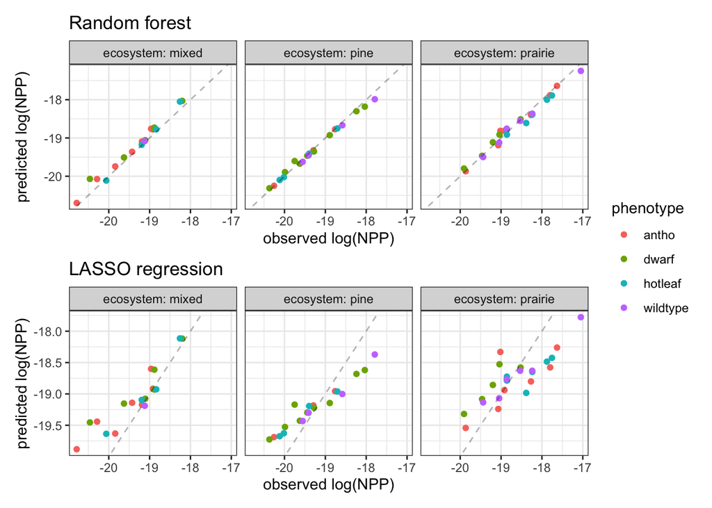

```r
(rf_pred_plot + labs(title = "Random forest")) /
  (lm_pred_plot + labs(title = "LASSO regression")) + plot_layout(guides = "collect")
```

## Spatial predictions

I generated a grid of points to predict summer average NPP after 10 years of growth at.

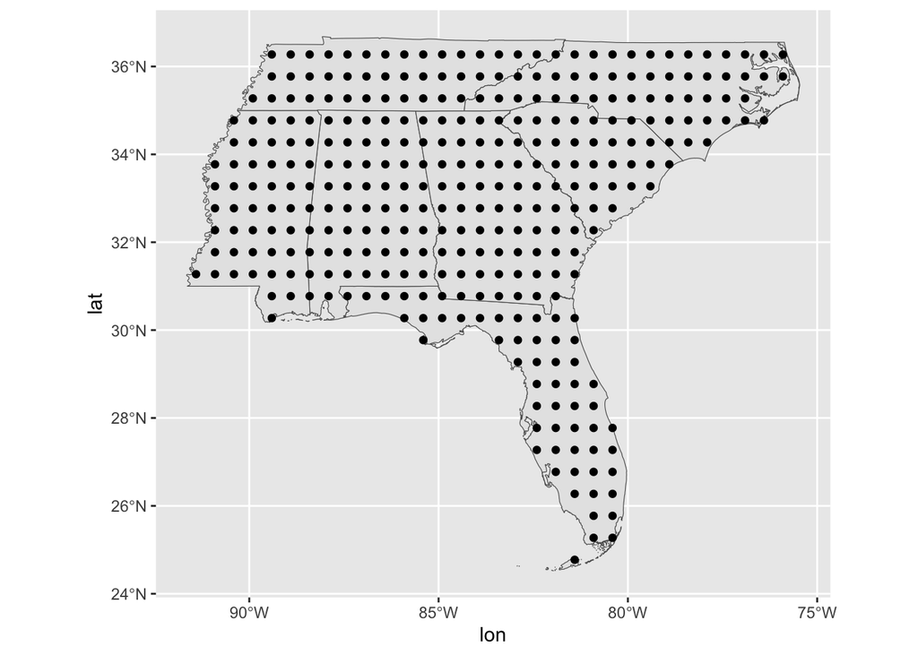

Grid of points 0.5º apart used for predicting mean summer NPP

```r
tar_load(c(seus, grid_data))
ggplot() +
  geom_sf(data = seus) +
  geom_point(data = grid_data, aes(x = lon, y = lat))
```

The resulting predicted values look are plotted below for each ecosystem and phenotype

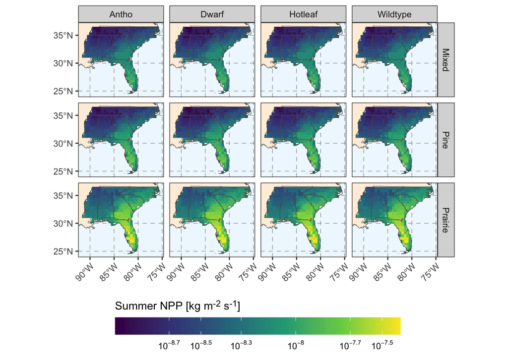

Predicted summer NPP for four phenotypes of *Setaria* in three simulated ecosystems. NPP values were predicted using a random forest model trained on ED2 simulations at 29 sites and 3 ecosystems per site. NPP values are predicted on a 0.5º grid and displayed on a log scale.

```r
tar_read(pred_map)
```

We can also visualize these as deviations from wildtype

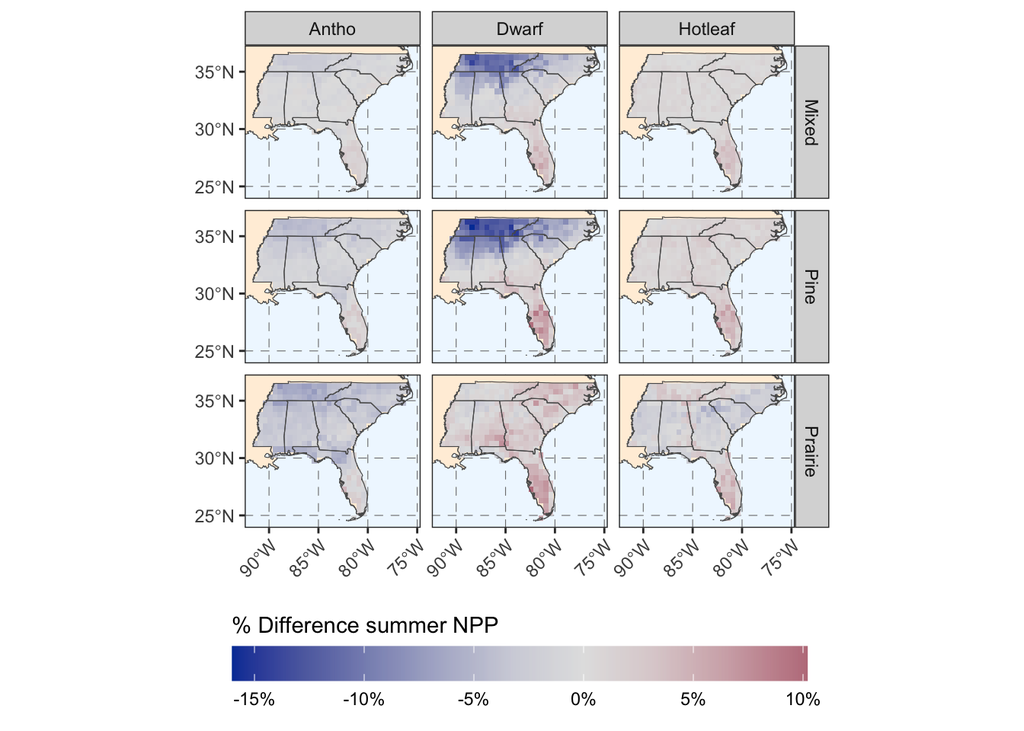

Percent difference in summer NPP compared to wildtype *Setaria* predicted in the South East US.

```r
tar_read(pred_map_diff)
```

## References

Frick, H., F. Chow, M. Kuhn, M. Mahoney, J. Silge, and H. Wickham. 2022. [Rsample: General resampling infrastructure](https://rsample.tidymodels.org).

Friedman, J. H., T. Hastie, and R. Tibshirani. 2010. [Regularization Paths for Generalized Linear Models via Coordinate Descent](https://doi.org/10.18637/jss.v033.i01). Journal of Statistical Software 33:1–22.

Hijmans, R. J. 2023. [Terra: Spatial data analysis](https://rspatial.org/).

Hijmans, R. J., S. Phillips, J. Leathwick, and J. Elith. 2022. [Dismo: Species distribution modeling](https://rspatial.org/raster/sdm/).

Hufkens, K., D. Basler, T. Milliman, E. K. Melaas, and A. D. Richardson. 2018. [An integrated phenology modelling framework in r](https://doi.org/10.1111/2041-210X.12970). Methods in Ecology and Evolution 9:1276–1285.

Kuhn, M., and H. Wickham. 2020. [Tidymodels: A collection of packages for modeling and machine learning using tidyverse principles.](https://www.tidymodels.org)

Kuhn, M., H. Wickham, and E. Hvitfeldt. 2023. [Recipes: Preprocessing and feature engineering steps for modeling](https://recipes.tidymodels.org/).

Pebesma, E. 2018. [Simple Features for R: Standardized Support for Spatial Vector Data](https://doi.org/10.32614/RJ-2018-009). The R Journal 10:439–446.

Pebesma, E., and R. Bivand. 2023. [Spatial data science: With applications in r](https://doi.org/10.1201/9780429459016). Page 352.

Tay, J. K., B. Narasimhan, and T. Hastie. 2023. [Elastic Net Regularization Paths for All Generalized Linear Models](https://doi.org/10.18637/jss.v106.i01). Journal of Statistical Software 106.

Wright, M. N., and A. Ziegler. 2017. [Ranger: A fast implementation of random forests for high dimensional data in C++ and R](https://doi.org/10.18637/jss.v077.i01). Journal of Statistical Software 77:1–17.